# STSCI 5065 - Lecture 07

MapReduce (M/R) Part 2

Harry Lu

# 1 What Have We Done in Part 1?

# 2 Hadoop Streaming

- A Hadoop API to MapReduce that allows writing the map and reduce functions in languages other than Java
- It uses Linux/Unix standard streams as the interface between Hadoop and your program, so you can use any programming language that can read standard input and write to standard output to write your MapReduce programs
- A map output key/value pair is written as a single tabdelimited line. Input to the reduce function is in the same format, a tab-separated key/value pair, passed over standard input. The reduce function reads lines from standard input, which the framework guarantees to be sorted by keys, and writes its results to standard output

# 3 What to Do?

- Use the Hadoop Streaming to pass data from the Mapper to the Reducer via **STDIN** (standard input) and **STDOUT** (standard output)
- Just simply use Python’s `sys.stdin` to read input data and print the output to `sys.stdout`
- The rest is taken care by Hadoop Streaming API!

# 4 Use Hadoop Streaming to Process the Temperature Data (for HDP 2.5)

```
hadoop jar /usr/hdp/2.5.0.0-1245/hadoop-mapreduce/hadoop-streaming.jar -file temp_map.py -file temp_reduce.py -mapper temp_map.py -reducer temp_reduce.py -input /stsci5065/data/1901-1 -output /stsci5065/maxtemp-output
```

# 5 Use Hadoop Streaming to Process the Temperature Data (for HDP 2.6.1)

- Put your executable mapper and reducer Python programs in current directory; otherwise, give the full path of these files.
- Run Python M/R functions against the 1901-1 global temperature dataset through Hadoop streaming with the following commands at the CentOS prompt:

```
hadoop jar /usr/hdp/2.6.1.0-129/hadoop-mapreduce/hadoop-streaming.jar -file temp_map.py -file temp_reduce.py -mapper temp_map.py -reducer temp_reduce.py -input /stsci5065/data/1901-1 -output /stsci5065/maxtemp-output
```

# 6 The Hadoop Streaming Was Successful

## 6.1 The Beginning of the Processing Log

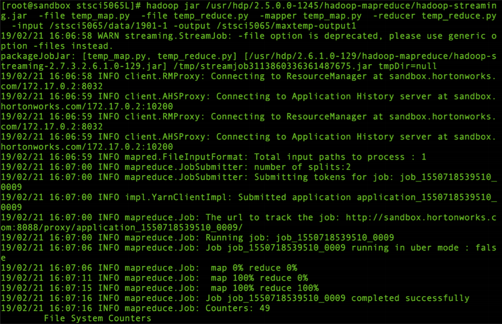

## 6.2 The End of the Processing Log

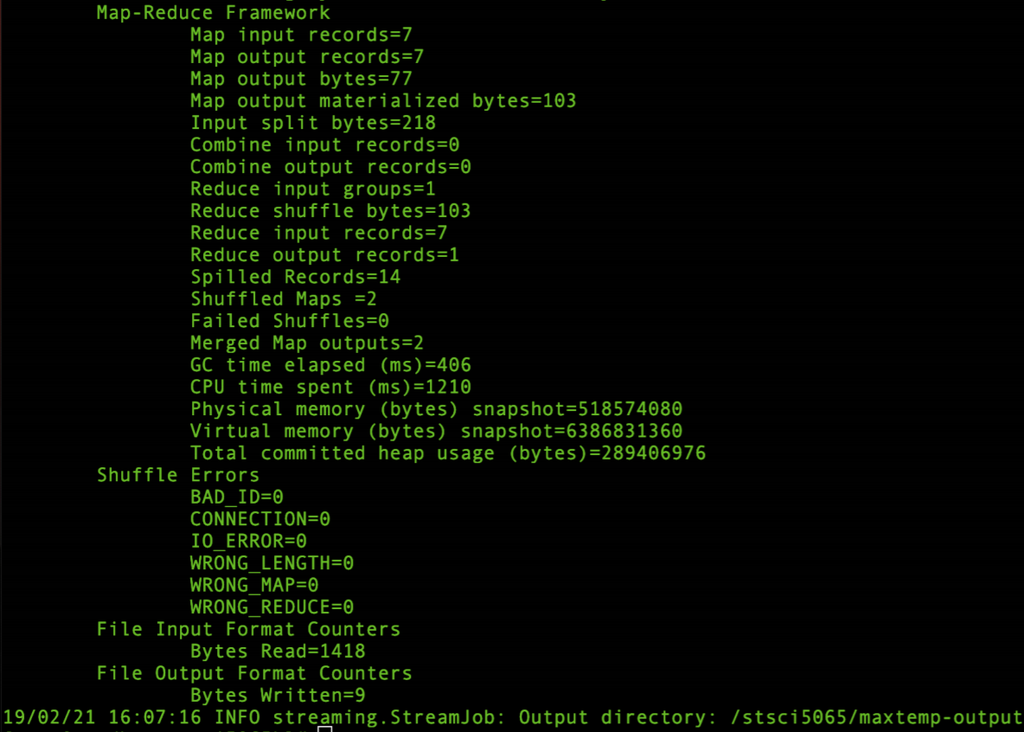

# 7 Check the Output

- The output was written to a file called `part-00000` in the `maxtemp-output` directory in the HDFS

```
[root@sandbox ~]# hadoop fs -cat /stsci5065/maxtemp-output/part-00000
     V
1901    -28
```

- You may also use Ambari’s Files View to display this file

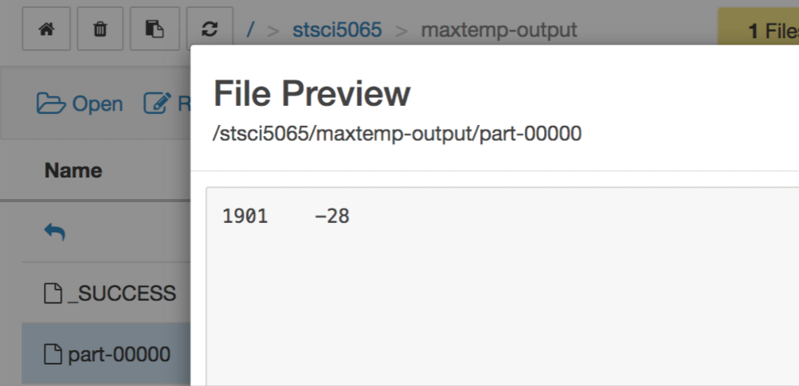

# 8 Apply Hadoop Streaming to the 1901-1902 File, a Single File

```
hadoop jar /usr/hdp/2.5.0.0-1245/hadoop-mapreduce/hadoop-streaming.jar -file temp_map.py -file temp_reduce.py -mapper temp_map.py -reducer temp_reduce.py -input /stsci5065/data/1901-1902 -output /stsci5065/maxtemp-output1
```

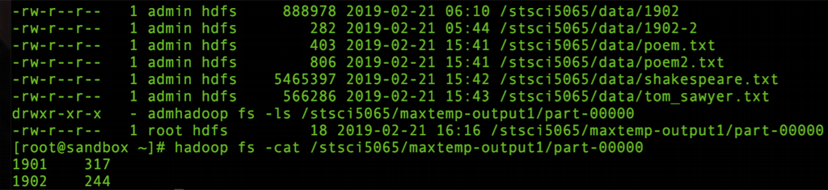

# 9 Apply Hadoop Streaming to all the files in a directory, 1901 and 1902 Files: the Same Results

```
hadoop jar /usr/hdp/2.5.0.0-1245/hadoop-mapreduce/hadoop-streaming.jar -file temp_map.py -file temp_reduce.py -mapper temp_map.py -reducer temp_reduce.py -input /stsci5065/data/two-files -output /stsci5065/maxtemp-output2
```

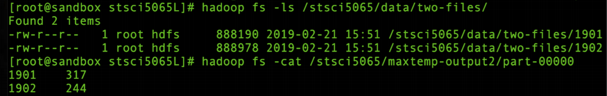

# 10 Another Example: Word Counting

- In this example, using Python programs (the mapper and reducer), we read some text files and count how often the words occur
- The input is a text file(s)
- The output is a text file(s), each line of which contains a word and the count of how many times it occurred, separated by a tab

## 10.1 The Mapper

`WDmapper.py`:

```
#!/usr/bin/env python

import sys

# input from STDIN
for line in sys.stdin:
    line = line.strip()
    words = line.split()
    for word in words:
        # the output values are tab-delimited
        # the word count is 1 since each for loop only reads one word
        print "%s\t%s" % (word, 1)
```

## 10.2 The Shuffle

- A lot happens between the map and reduce steps that is largely transparent to the developer
- In brief, the output of the mappers is transformed and distributed to the reducers (termed the shuffle step) in such a way that
  - All key/value pairs are sorted before being presented to the reduce function
  - All key/value pairs sharing the same key are sent to the same reducer

## 10.3 The Reducer

`WDreducer.py`:

```
#!/usr/bin/env python

import sys

current_word = None
current_count = 0
word = None

# input comes from STDIN
for line in sys.stdin:
    line = line.strip()

    # parse the input we got from WDmapper.py
    word, count = line.split("\t", 1)

    # convert count (a string) to int
    try:
        count = int(count)
    except ValueError:
        # if count was not a number, silently ignore the line
        continue

    # Hadoop sorts map output by key (here: word) before it is passes to the reducer
    if current_word == word:
        current_count = current_count + count
    else:
        if current_word:
            # write result to STDOUT
            print "%s\t%s" % (current_word, current_count)
        current_count = count
        current_word = word

# output the last word if needed
if current_word == word:
    print "%s\t%s" % (current_word, current_count)
```

## 10.4 Add the Execution Permission to Files

- The original file permissions of `WDmapper.py` and `WDreducer.py` are `rw-r--r--`
- The execution permission needs to be added to the files. This time we use the following commands:

```
chmod +x /stsci5065/WDmapper.py
chmod +x /stsci5065/WDreducer.py
```

- Their file permissions became `rwxr-xr-x`

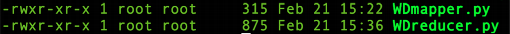

## 10.5 First Test Your Code Locally

- Test the mapper, `WDmapper.py`

```
cat ./poem.txt | ./WDmapper.py
```

[figure not shown]

- Test the reducer, `WDreducer.py` with the mapper

```
cat ./poem.txt | ./WDmapper.py | sort | ./WDreducer.py
```

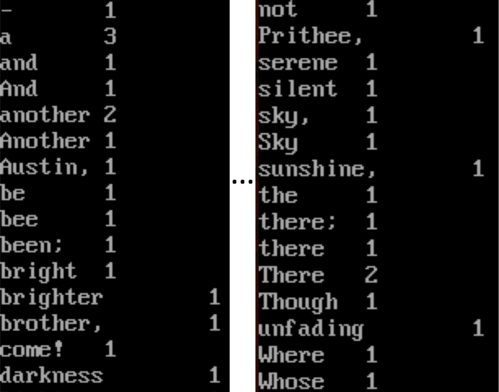

# 11 Hadoop Streaming on `Shakespeare.txt`

```
hadoop jar /usr/hdp/2.5.0.0-1245/hadoop-mapreduce/hadoop-streaming.jar -file WDmapper.py -file WDreducer.py -mapper WDmapper.py -reducer WDreducer.py -input /stsci5065/data/shakespeare.txt -output /stsci5065/maxtemp-output3
```

## 11.1 The Streaming Results

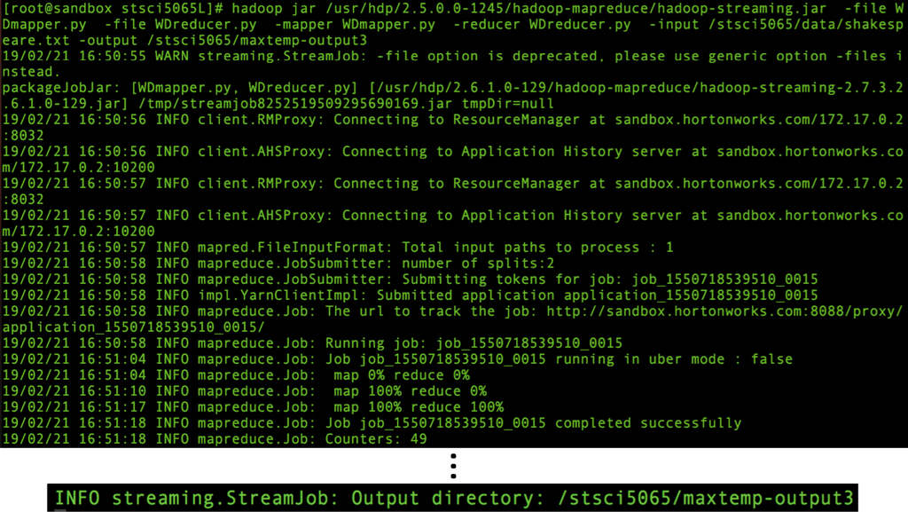

## 11.2 The Output

```
hadoop fs -cat /stsci5065/maxtemp-output3/part-00000
```

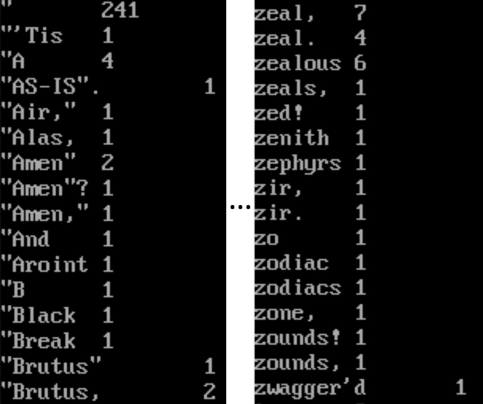